# Scikit learn pipeline

```python
import numpy as np
import pandas as pd
```

Numpy is the most important library for manipulating arrays and doing calculations. Pandas is a data analysis library, we're going to need it to manipulate dataframes. Of course we need to run conda install numpy pands to install the packages

conda install -c conda-forge jupyter_contrib_nbextensions To enable plugin autocompletion in the notebook

```python
train_file = "train.csv"
test_file = "test.csv"
train = pd.read_csv(train_file)
test = pd.read_csv(test_file)
```

Load the train and test csv files into a Pandas datafram each

```python
train
```

|  | id | species | margin1 | margin2 | margin3 | margin4 | margin5 | margin6 | margin7 | margin8 | ... | texture55 | texture56 | texture57 | texture58 | texture59 | texture60 | texture61 | texture62 | texture63 | texture64 |
| --- | --- | --- | --- | --- | --- | --- | --- | --- | --- | --- | --- | --- | --- | --- | --- | --- | --- | --- | --- | --- | --- |
| 0 | 1 | Acer_Opalus | 0.007812 | 0.023438 | 0.023438 | 0.003906 | 0.011719 | 0.009766 | 0.027344 | 0.000000 | ... | 0.007812 | 0.000000 | 0.002930 | 0.002930 | 0.035156 | 0.000000 | 0.000000 | 0.004883 | 0.000000 | 0.025391 |
| 1 | 2 | Pterocarya_Stenoptera | 0.005859 | 0.000000 | 0.031250 | 0.015625 | 0.025391 | 0.001953 | 0.019531 | 0.000000 | ... | 0.000977 | 0.000000 | 0.000000 | 0.000977 | 0.023438 | 0.000000 | 0.000000 | 0.000977 | 0.039062 | 0.022461 |
| 2 | 3 | Quercus_Hartwissiana | 0.005859 | 0.009766 | 0.019531 | 0.007812 | 0.003906 | 0.005859 | 0.068359 | 0.000000 | ... | 0.154300 | 0.000000 | 0.005859 | 0.000977 | 0.007812 | 0.000000 | 0.000000 | 0.000000 | 0.020508 | 0.002930 |
| 3 | 5 | Tilia_Tomentosa | 0.000000 | 0.003906 | 0.023438 | 0.005859 | 0.021484 | 0.019531 | 0.023438 | 0.000000 | ... | 0.000000 | 0.000977 | 0.000000 | 0.000000 | 0.020508 | 0.000000 | 0.000000 | 0.017578 | 0.000000 | 0.047852 |
| 4 | 6 | Quercus_Variabilis | 0.005859 | 0.003906 | 0.048828 | 0.009766 | 0.013672 | 0.015625 | 0.005859 | 0.000000 | ... | 0.096680 | 0.000000 | 0.021484 | 0.000000 | 0.000000 | 0.000000 | 0.000000 | 0.000000 | 0.000000 | 0.031250 |
| 5 | 8 | Magnolia_Salicifolia | 0.070312 | 0.093750 | 0.033203 | 0.001953 | 0.000000 | 0.152340 | 0.007812 | 0.000000 | ... | 0.145510 | 0.000000 | 0.041992 | 0.000000 | 0.005859 | 0.000000 | 0.000000 | 0.000000 | 0.001953 | 0.013672 |
| 6 | 10 | Quercus_Canariensis | 0.021484 | 0.031250 | 0.017578 | 0.009766 | 0.001953 | 0.042969 | 0.039062 | 0.000000 | ... | 0.085938 | 0.000000 | 0.040039 | 0.000000 | 0.009766 | 0.000000 | 0.000000 | 0.000000 | 0.039062 | 0.003906 |
| 7 | 11 | Quercus_Rubra | 0.000000 | 0.000000 | 0.037109 | 0.050781 | 0.003906 | 0.000000 | 0.003906 | 0.000000 | ... | 0.038086 | 0.025391 | 0.009766 | 0.002930 | 0.021484 | 0.000000 | 0.037109 | 0.006836 | 0.002930 | 0.036133 |
| 8 | 14 | Quercus_Brantii | 0.005859 | 0.001953 | 0.033203 | 0.015625 | 0.001953 | 0.000000 | 0.023438 | 0.000000 | ... | 0.000000 | 0.000000 | 0.008789 | 0.000000 | 0.017578 | 0.000000 | 0.000000 | 0.000977 | 0.033203 | 0.074219 |
| 9 | 15 | Salix_Fragilis | 0.000000 | 0.000000 | 0.009766 | 0.037109 | 0.072266 | 0.000000 | 0.000000 | 0.000000 | ... | 0.000000 | 0.000000 | 0.000000 | 0.070312 | 0.013672 | 0.192380 | 0.000000 | 0.074219 | 0.000000 | 0.000000 |
| 10 | 17 | Zelkova_Serrata | 0.019531 | 0.031250 | 0.001953 | 0.005859 | 0.003906 | 0.013672 | 0.033203 | 0.000000 | ... | 0.009766 | 0.000000 | 0.000000 | 0.002930 | 0.024414 | 0.000000 | 0.000000 | 0.006836 | 0.000000 | 0.004883 |
| 11 | 18 | Betula_Austrosinensis | 0.001953 | 0.001953 | 0.023438 | 0.025391 | 0.076172 | 0.000000 | 0.029297 | 0.000000 | ... | 0.013672 | 0.003906 | 0.014648 | 0.003906 | 0.036133 | 0.000000 | 0.000000 | 0.012695 | 0.005859 | 0.000000 |
| 12 | 20 | Quercus_Pontica | 0.015625 | 0.011719 | 0.041016 | 0.003906 | 0.023438 | 0.015625 | 0.019531 | 0.000000 | ... | 0.003906 | 0.000000 | 0.086914 | 0.000000 | 0.013672 | 0.000000 | 0.000000 | 0.000000 | 0.011719 | 0.002930 |
| 13 | 21 | Quercus_Afares | 0.011719 | 0.011719 | 0.054688 | 0.017578 | 0.007812 | 0.009766 | 0.011719 | 0.007812 | ... | 0.002930 | 0.000000 | 0.015625 | 0.000000 | 0.015625 | 0.000000 | 0.000000 | 0.000000 | 0.018555 | 0.022461 |
| 14 | 22 | Quercus_Coccifera | 0.011719 | 0.007812 | 0.111330 | 0.027344 | 0.023438 | 0.039062 | 0.013672 | 0.000000 | ... | 0.000977 | 0.001953 | 0.000000 | 0.034180 | 0.007812 | 0.038086 | 0.000000 | 0.089844 | 0.023438 | 0.001953 |
| 15 | 25 | Fagus_Sylvatica | 0.027344 | 0.025391 | 0.066406 | 0.007812 | 0.003906 | 0.052734 | 0.031250 | 0.000000 | ... | 0.008789 | 0.000000 | 0.004883 | 0.004883 | 0.009766 | 0.001953 | 0.000000 | 0.003906 | 0.000000 | 0.036133 |
| 16 | 26 | Phildelphus | 0.009766 | 0.062500 | 0.033203 | 0.029297 | 0.011719 | 0.044922 | 0.005859 | 0.000000 | ... | 0.000000 | 0.000000 | 0.004883 | 0.000000 | 0.068359 | 0.000000 | 0.000000 | 0.000000 | 0.036133 | 0.000977 |
| 17 | 27 | Acer_Palmatum | 0.000000 | 0.000000 | 0.001953 | 0.029297 | 0.111330 | 0.000000 | 0.000000 | 0.000000 | ... | 0.012695 | 0.000000 | 0.079102 | 0.000000 | 0.000000 | 0.000000 | 0.000000 | 0.000000 | 0.000000 | 0.019531 |
| 18 | 29 | Quercus_Pubescens | 0.001953 | 0.000000 | 0.015625 | 0.031250 | 0.011719 | 0.000000 | 0.021484 | 0.001953 | ... | 0.000000 | 0.000000 | 0.001953 | 0.005859 | 0.049805 | 0.000000 | 0.000000 | 0.006836 | 0.000000 | 0.001953 |
| 19 | 30 | Populus_Adenopoda | 0.005859 | 0.027344 | 0.017578 | 0.041016 | 0.007812 | 0.017578 | 0.046875 | 0.001953 | ... | 0.000000 | 0.000977 | 0.000000 | 0.020508 | 0.001953 | 0.333010 | 0.000000 | 0.169920 | 0.000000 | 0.000000 |
| 20 | 31 | Quercus_Trojana | 0.019531 | 0.019531 | 0.064453 | 0.025391 | 0.007812 | 0.005859 | 0.023438 | 0.000000 | ... | 0.000000 | 0.000977 | 0.001953 | 0.016602 | 0.023438 | 0.004883 | 0.000000 | 0.003906 | 0.013672 | 0.004883 |
| 21 | 32 | Quercus_Variabilis | 0.019531 | 0.029297 | 0.080078 | 0.033203 | 0.025391 | 0.023438 | 0.009766 | 0.005859 | ... | 0.021484 | 0.000000 | 0.057617 | 0.000000 | 0.002930 | 0.000000 | 0.000000 | 0.000000 | 0.000000 | 0.035156 |
| 22 | 34 | Alnus_Sieboldiana | 0.000000 | 0.005859 | 0.023438 | 0.001953 | 0.013672 | 0.001953 | 0.015625 | 0.000000 | ... | 0.000000 | 0.019531 | 0.000000 | 0.031250 | 0.005859 | 0.054688 | 0.000000 | 0.103520 | 0.000977 | 0.000000 |
| 23 | 35 | Quercus_Ilex | 0.029297 | 0.033203 | 0.033203 | 0.021484 | 0.001953 | 0.068359 | 0.037109 | 0.000000 | ... | 0.000000 | 0.000000 | 0.000000 | 0.044922 | 0.003906 | 0.004883 | 0.000000 | 0.069336 | 0.000000 | 0.000000 |
| 24 | 37 | Arundinaria_Simonii | 0.001953 | 0.023438 | 0.005859 | 0.029297 | 0.000000 | 0.000000 | 0.000000 | 0.000000 | ... | 0.103520 | 0.009766 | 0.000000 | 0.002930 | 0.002930 | 0.077148 | 0.000000 | 0.052734 | 0.000000 | 0.000000 |
| 25 | 38 | Acer_Platanoids | 0.015625 | 0.031250 | 0.101560 | 0.015625 | 0.005859 | 0.017578 | 0.000000 | 0.000000 | ... | 0.029297 | 0.033203 | 0.007812 | 0.006836 | 0.014648 | 0.000000 | 0.000000 | 0.020508 | 0.000000 | 0.035156 |
| 26 | 40 | Quercus_Phillyraeoides | 0.027344 | 0.009766 | 0.021484 | 0.042969 | 0.017578 | 0.009766 | 0.037109 | 0.031250 | ... | 0.000000 | 0.000000 | 0.003906 | 0.000977 | 0.009766 | 0.001953 | 0.000000 | 0.001953 | 0.023438 | 0.007812 |
| 27 | 42 | Cornus_Chinensis | 0.085938 | 0.095703 | 0.007812 | 0.003906 | 0.000000 | 0.148440 | 0.007812 | 0.000000 | ... | 0.018555 | 0.052734 | 0.005859 | 0.000977 | 0.019531 | 0.000000 | 0.011719 | 0.041992 | 0.004883 | 0.020508 |
| 28 | 43 | Quercus_Phillyraeoides | 0.001953 | 0.003906 | 0.017578 | 0.044922 | 0.041016 | 0.011719 | 0.039062 | 0.013672 | ... | 0.000000 | 0.000000 | 0.000000 | 0.000977 | 0.007812 | 0.000000 | 0.000000 | 0.007812 | 0.024414 | 0.015625 |
| 29 | 45 | Fagus_Sylvatica | 0.019531 | 0.041016 | 0.093750 | 0.005859 | 0.011719 | 0.037109 | 0.035156 | 0.000000 | ... | 0.076172 | 0.000000 | 0.049805 | 0.000000 | 0.000977 | 0.000000 | 0.000000 | 0.000000 | 0.000000 | 0.001953 |
| ... | ... | ... | ... | ... | ... | ... | ... | ... | ... | ... | ... | ... | ... | ... | ... | ... | ... | ... | ... | ... | ... |
| 960 | 1541 | Quercus_Vulcanica | 0.003906 | 0.000000 | 0.013672 | 0.029297 | 0.007812 | 0.005859 | 0.019531 | 0.000000 | ... | 0.000000 | 0.000000 | 0.013672 | 0.000000 | 0.019531 | 0.000000 | 0.000000 | 0.003906 | 0.029297 | 0.055664 |
| 961 | 1543 | Salix_Fragilis | 0.000000 | 0.000000 | 0.007812 | 0.015625 | 0.072266 | 0.000000 | 0.011719 | 0.003906 | ... | 0.000000 | 0.000000 | 0.000000 | 0.041016 | 0.057617 | 0.011719 | 0.000000 | 0.010742 | 0.000000 | 0.002930 |
| 962 | 1544 | Tilia_Tomentosa | 0.000000 | 0.017578 | 0.015625 | 0.011719 | 0.037109 | 0.003906 | 0.019531 | 0.000000 | ... | 0.000000 | 0.002930 | 0.000000 | 0.015625 | 0.029297 | 0.000000 | 0.000000 | 0.030273 | 0.000000 | 0.012695 |
| 963 | 1545 | Populus_Grandidentata | 0.009766 | 0.011719 | 0.121090 | 0.003906 | 0.009766 | 0.009766 | 0.007812 | 0.005859 | ... | 0.213870 | 0.000000 | 0.041016 | 0.000000 | 0.003906 | 0.000000 | 0.000000 | 0.000000 | 0.000000 | 0.014648 |
| 964 | 1547 | Prunus_X_Shmittii | 0.001953 | 0.001953 | 0.007812 | 0.019531 | 0.037109 | 0.000000 | 0.013672 | 0.000000 | ... | 0.000000 | 0.000000 | 0.003906 | 0.000977 | 0.039062 | 0.000000 | 0.000000 | 0.000000 | 0.022461 | 0.033203 |
| 965 | 1548 | Quercus_x_Hispanica | 0.003906 | 0.003906 | 0.033203 | 0.037109 | 0.003906 | 0.003906 | 0.031250 | 0.000000 | ... | 0.000000 | 0.000000 | 0.000000 | 0.011719 | 0.028320 | 0.000000 | 0.000000 | 0.011719 | 0.008789 | 0.000000 |
| 966 | 1549 | Quercus_Suber | 0.011719 | 0.005859 | 0.048828 | 0.009766 | 0.003906 | 0.046875 | 0.050781 | 0.000000 | ... | 0.000000 | 0.000000 | 0.000000 | 0.039062 | 0.000977 | 0.008789 | 0.000000 | 0.032227 | 0.000000 | 0.000977 |
| 967 | 1550 | Alnus_Viridis | 0.000000 | 0.000000 | 0.005859 | 0.013672 | 0.031250 | 0.000000 | 0.011719 | 0.000000 | ... | 0.000000 | 0.020508 | 0.002930 | 0.009766 | 0.026367 | 0.000000 | 0.000000 | 0.009766 | 0.011719 | 0.041016 |
| 968 | 1551 | Acer_Palmatum | 0.000000 | 0.000000 | 0.003906 | 0.039062 | 0.082031 | 0.000000 | 0.000000 | 0.000000 | ... | 0.007812 | 0.000000 | 0.144530 | 0.000000 | 0.000000 | 0.000000 | 0.000000 | 0.000000 | 0.000000 | 0.010742 |
| 969 | 1552 | Quercus_Rhysophylla | 0.025391 | 0.042969 | 0.025391 | 0.033203 | 0.001953 | 0.033203 | 0.011719 | 0.000000 | ... | 0.000000 | 0.147460 | 0.000977 | 0.018555 | 0.008789 | 0.009766 | 0.000000 | 0.078125 | 0.022461 | 0.000000 |
| 970 | 1554 | Quercus_Cerris | 0.011719 | 0.013672 | 0.021484 | 0.031250 | 0.017578 | 0.003906 | 0.025391 | 0.003906 | ... | 0.000000 | 0.000000 | 0.002930 | 0.000000 | 0.019531 | 0.000000 | 0.000000 | 0.001953 | 0.010742 | 0.067383 |
| 971 | 1555 | Quercus_Texana | 0.000000 | 0.005859 | 0.072266 | 0.076172 | 0.007812 | 0.000000 | 0.000000 | 0.000000 | ... | 0.040039 | 0.000977 | 0.006836 | 0.002930 | 0.022461 | 0.000000 | 0.082031 | 0.001953 | 0.005859 | 0.029297 |
| 972 | 1556 | Acer_Mono | 0.029297 | 0.005859 | 0.056641 | 0.031250 | 0.000000 | 0.021484 | 0.031250 | 0.003906 | ... | 0.109380 | 0.000000 | 0.013672 | 0.004883 | 0.018555 | 0.000000 | 0.000000 | 0.001953 | 0.000977 | 0.004883 |
| 973 | 1557 | Quercus_Vulcanica | 0.011719 | 0.005859 | 0.001953 | 0.003906 | 0.011719 | 0.011719 | 0.031250 | 0.000000 | ... | 0.066406 | 0.000000 | 0.096680 | 0.000000 | 0.006836 | 0.000000 | 0.000000 | 0.000000 | 0.030273 | 0.011719 |
| 974 | 1559 | Quercus_Nigra | 0.037109 | 0.056641 | 0.019531 | 0.021484 | 0.001953 | 0.068359 | 0.015625 | 0.000000 | ... | 0.046875 | 0.000000 | 0.009766 | 0.000000 | 0.010742 | 0.000000 | 0.000977 | 0.005859 | 0.011719 | 0.002930 |
| 975 | 1561 | Rhododendron_x_Russellianum | 0.074219 | 0.093750 | 0.007812 | 0.013672 | 0.000000 | 0.119140 | 0.003906 | 0.000000 | ... | 0.000000 | 0.000000 | 0.000000 | 0.005859 | 0.007812 | 0.000000 | 0.000000 | 0.030273 | 0.012695 | 0.000977 |
| 976 | 1562 | Acer_Capillipes | 0.000000 | 0.000000 | 0.013672 | 0.015625 | 0.048828 | 0.000000 | 0.033203 | 0.000000 | ... | 0.094727 | 0.000000 | 0.016602 | 0.000000 | 0.018555 | 0.000000 | 0.000000 | 0.000977 | 0.028320 | 0.000000 |
| 977 | 1563 | Quercus_Pubescens | 0.001953 | 0.000000 | 0.041016 | 0.015625 | 0.015625 | 0.000000 | 0.009766 | 0.000000 | ... | 0.000000 | 0.000000 | 0.017578 | 0.011719 | 0.070312 | 0.000000 | 0.000000 | 0.000977 | 0.000000 | 0.012695 |
| 978 | 1566 | Alnus_Viridis | 0.000000 | 0.000000 | 0.007812 | 0.007812 | 0.039062 | 0.000000 | 0.001953 | 0.005859 | ... | 0.000000 | 0.056641 | 0.000000 | 0.035156 | 0.011719 | 0.024414 | 0.000000 | 0.066406 | 0.013672 | 0.000000 |
| 979 | 1568 | Quercus_x_Hispanica | 0.009766 | 0.003906 | 0.025391 | 0.017578 | 0.005859 | 0.003906 | 0.035156 | 0.000000 | ... | 0.000000 | 0.000000 | 0.000000 | 0.008789 | 0.016602 | 0.000000 | 0.000000 | 0.024414 | 0.037109 | 0.003906 |
| 980 | 1569 | Quercus_Suber | 0.031250 | 0.009766 | 0.078125 | 0.017578 | 0.003906 | 0.058594 | 0.048828 | 0.000000 | ... | 0.000977 | 0.000000 | 0.024414 | 0.006836 | 0.017578 | 0.000977 | 0.000000 | 0.016602 | 0.000000 | 0.041016 |
| 981 | 1570 | Viburnum_x_Rhytidophylloides | 0.027344 | 0.044922 | 0.023438 | 0.017578 | 0.001953 | 0.025391 | 0.083984 | 0.000000 | ... | 0.000000 | 0.000000 | 0.000000 | 0.036133 | 0.082031 | 0.000000 | 0.000000 | 0.026367 | 0.008789 | 0.000000 |
| 982 | 1571 | Quercus_Nigra | 0.017578 | 0.074219 | 0.015625 | 0.013672 | 0.000000 | 0.074219 | 0.005859 | 0.000000 | ... | 0.025391 | 0.000000 | 0.003906 | 0.000000 | 0.009766 | 0.000000 | 0.012695 | 0.000000 | 0.009766 | 0.000000 |
| 983 | 1572 | Quercus_Phellos | 0.023438 | 0.076172 | 0.015625 | 0.019531 | 0.000000 | 0.039062 | 0.011719 | 0.000000 | ... | 0.053711 | 0.000000 | 0.002930 | 0.000977 | 0.005859 | 0.000000 | 0.081055 | 0.000000 | 0.003906 | 0.019531 |
| 984 | 1574 | Ilex_Cornuta | 0.080078 | 0.048828 | 0.023438 | 0.007812 | 0.000000 | 0.091797 | 0.009766 | 0.000000 | ... | 0.003906 | 0.003906 | 0.041016 | 0.006836 | 0.017578 | 0.000000 | 0.000000 | 0.003906 | 0.000977 | 0.032227 |
| 985 | 1575 | Magnolia_Salicifolia | 0.060547 | 0.119140 | 0.007812 | 0.003906 | 0.000000 | 0.148440 | 0.017578 | 0.000000 | ... | 0.242190 | 0.000000 | 0.034180 | 0.000000 | 0.010742 | 0.000000 | 0.000000 | 0.000000 | 0.000000 | 0.018555 |
| 986 | 1578 | Acer_Pictum | 0.001953 | 0.003906 | 0.021484 | 0.107420 | 0.001953 | 0.000000 | 0.000000 | 0.000000 | ... | 0.170900 | 0.000000 | 0.018555 | 0.000000 | 0.011719 | 0.000000 | 0.000000 | 0.000977 | 0.000000 | 0.021484 |
| 987 | 1581 | Alnus_Maximowiczii | 0.001953 | 0.003906 | 0.000000 | 0.021484 | 0.078125 | 0.003906 | 0.007812 | 0.000000 | ... | 0.004883 | 0.000977 | 0.004883 | 0.027344 | 0.016602 | 0.007812 | 0.000000 | 0.027344 | 0.000000 | 0.001953 |
| 988 | 1582 | Quercus_Rubra | 0.000000 | 0.000000 | 0.046875 | 0.056641 | 0.009766 | 0.000000 | 0.000000 | 0.000000 | ... | 0.083008 | 0.030273 | 0.000977 | 0.002930 | 0.014648 | 0.000000 | 0.041992 | 0.000000 | 0.001953 | 0.002930 |
| 989 | 1584 | Quercus_Afares | 0.023438 | 0.019531 | 0.031250 | 0.015625 | 0.005859 | 0.019531 | 0.035156 | 0.000000 | ... | 0.000000 | 0.000000 | 0.002930 | 0.000000 | 0.012695 | 0.000000 | 0.000000 | 0.023438 | 0.025391 | 0.022461 |

990 rows × 194 columns

```python
train["species"].value_counts()
```

```
Quercus_Trojana                 10
Cornus_Chinensis                10
Viburnum_x_Rhytidophylloides    10
Magnolia_Salicifolia            10
Quercus_x_Turneri               10
Prunus_Avium                    10
Lithocarpus_Edulis              10
Ulmus_Bergmanniana              10
Quercus_Variabilis              10
Quercus_Rubra                   10
Populus_Adenopoda               10
Quercus_Alnifolia               10
Quercus_Phillyraeoides          10
Quercus_x_Hispanica             10
Quercus_Hartwissiana            10
Betula_Austrosinensis           10
Cornus_Controversa              10
Quercus_Infectoria_sub          10
Quercus_Ilex                    10
Magnolia_Heptapeta              10
Quercus_Chrysolepis             10
Quercus_Afares                  10
Callicarpa_Bodinieri            10
Crataegus_Monogyna              10
Acer_Saccharinum                10
Acer_Pictum                     10
Tilia_Oliveri                   10
Quercus_Cerris                  10
Quercus_Nigra                   10
Quercus_Imbricaria              10
                                ..
Zelkova_Serrata                 10
Quercus_Crassifolia             10
Arundinaria_Simonii             10
Quercus_Coccifera               10
Acer_Capillipes                 10
Liquidambar_Styraciflua         10
Acer_Rubrum                     10
Betula_Pendula                  10
Quercus_Semecarpifolia          10
Fagus_Sylvatica                 10
Acer_Palmatum                   10
Quercus_Vulcanica               10
Cotinus_Coggygria               10
Sorbus_Aria                     10
Ilex_Aquifolium                 10
Quercus_Ellipsoidalis           10
Alnus_Maximowiczii              10
Rhododendron_x_Russellianum     10
Quercus_Phellos                 10
Alnus_Cordata                   10
Quercus_Greggii                 10
Acer_Opalus                     10
Quercus_Castaneifolia           10
Quercus_Suber                   10
Alnus_Viridis                   10
Populus_Nigra                   10
Ilex_Cornuta                    10
Cornus_Macrophylla              10
Eucalyptus_Neglecta             10
Eucalyptus_Glaucescens          10
Name: species, Length: 99, dtype: int64
```

The dataframe contains 99 categorie of species, each category has 10 samples Also the task at hand is the **multiclass classification** so we're going to refer to some Popular multiclass classifier to do the job

We need to seperate the labels from the dataframe and convert the categorial labels into numerical labels for ease of manipulation and then to binary labels to drop the nearby similarity assumption that could be accounted for in the ML algorithm. To do this we'll use the LabelBinarizer from sklearn preprocessing tools.

[figure not shown]

```python
import numpy
# disable printing trancat to show the entire output
numpy.set_printoptions(threshold=numpy.inf)
```

```python
from sklearn.preprocessing import LabelBinarizer
encoder = LabelBinarizer()
binary_labels = encoder.fit_transform(train["species"])
binary_labels[1]
```

```
array([0, 0, 0, 0, 0, 0, 0, 0, 0, 0, 0, 0, 0, 0, 0, 0, 0, 0, 0, 0, 0, 0,
       0, 0, 0, 0, 0, 0, 0, 0, 0, 0, 0, 0, 0, 0, 0, 0, 0, 0, 0, 0, 0, 0,
       0, 0, 0, 0, 0, 1, 0, 0, 0, 0, 0, 0, 0, 0, 0, 0, 0, 0, 0, 0, 0, 0,
       0, 0, 0, 0, 0, 0, 0, 0, 0, 0, 0, 0, 0, 0, 0, 0, 0, 0, 0, 0, 0, 0,
       0, 0, 0, 0, 0, 0, 0, 0, 0, 0, 0])
```

Now we drop the image label and the species category columns from the training dataframe

```python
from pandas import DataFrame
train = DataFrame.copy(train.iloc[:, 2:])
train.head()
```

|  | margin1 | margin2 | margin3 | margin4 | margin5 | margin6 | margin7 | margin8 | margin9 | margin10 | ... | texture55 | texture56 | texture57 | texture58 | texture59 | texture60 | texture61 | texture62 | texture63 | texture64 |
| --- | --- | --- | --- | --- | --- | --- | --- | --- | --- | --- | --- | --- | --- | --- | --- | --- | --- | --- | --- | --- | --- |
| 0 | 0.007812 | 0.023438 | 0.023438 | 0.003906 | 0.011719 | 0.009766 | 0.027344 | 0.0 | 0.001953 | 0.033203 | ... | 0.007812 | 0.000000 | 0.002930 | 0.002930 | 0.035156 | 0.0 | 0.0 | 0.004883 | 0.000000 | 0.025391 |
| 1 | 0.005859 | 0.000000 | 0.031250 | 0.015625 | 0.025391 | 0.001953 | 0.019531 | 0.0 | 0.000000 | 0.007812 | ... | 0.000977 | 0.000000 | 0.000000 | 0.000977 | 0.023438 | 0.0 | 0.0 | 0.000977 | 0.039062 | 0.022461 |
| 2 | 0.005859 | 0.009766 | 0.019531 | 0.007812 | 0.003906 | 0.005859 | 0.068359 | 0.0 | 0.000000 | 0.044922 | ... | 0.154300 | 0.000000 | 0.005859 | 0.000977 | 0.007812 | 0.0 | 0.0 | 0.000000 | 0.020508 | 0.002930 |
| 3 | 0.000000 | 0.003906 | 0.023438 | 0.005859 | 0.021484 | 0.019531 | 0.023438 | 0.0 | 0.013672 | 0.017578 | ... | 0.000000 | 0.000977 | 0.000000 | 0.000000 | 0.020508 | 0.0 | 0.0 | 0.017578 | 0.000000 | 0.047852 |
| 4 | 0.005859 | 0.003906 | 0.048828 | 0.009766 | 0.013672 | 0.015625 | 0.005859 | 0.0 | 0.000000 | 0.005859 | ... | 0.096680 | 0.000000 | 0.021484 | 0.000000 | 0.000000 | 0.0 | 0.0 | 0.000000 | 0.000000 | 0.031250 |

5 rows × 192 columns

We drop the images labels from the test data too

```python
test = DataFrame.copy(test.iloc[:, 1:])
```

Now we're going to try a few machine learning classifiers such as see what are the best result we can drive and gain some more insight into the data.

# Random Forest tree

We're going to use grid search to fine tune the decision forest hyperparamters and cross validation to evaluate the model performance First we need to create the parameters grid to sample from during fitting:

```python
param_grid = [
        {
           'n_estimators' : [3, 10, 30, 300], # the number of trees in the forest
           'max_features' : [10, 30, 60] #Number of features to to consider when looking for the best split
        },
        {
         'bootstrap' : [False],
         'n_estimators' : [6, 12],
         'max_features' : [6, 7, 8]
        }
    ]
```

```python
from sklearn.model_selection import GridSearchCV
from sklearn.ensemble import RandomForestRegressor
def gridSearch(param_grid):
        forest_reg = RandomForestRegressor()
        grid_search = GridSearchCV(
            forest_reg,
            param_grid,
            cv=2,
            scoring='neg_mean_squared_error'
            )
        grid_search.fit(train, binary_labels)
        return grid_search
```

Than we evaluate the output of the grid search, we order the combinations of hyperparameters by score

```python
grid_search = gridSearch(param_grid)
```

```python
def ShowGridSearchResult(grid_search):
    cvres = grid_search.cv_results_
    #Create dataframe from grid search result for pretty priting
    scores_data_frame = DataFrame(data = cvres)
    #Take only mean test score and associated params rows
    scores_data_frame = scores_data_frame[['mean_test_score', 'params']]
    #order rows by means test sore
    scores_data_frame.sort_values(by=['mean_test_score'], inplace = True, ascending = False)
    #Disable cell content truncating to show the full content
    pd.set_option('display.max_colwidth', -1)
    #Show the dataframe
    display(scores_data_frame)
```

```python
ShowGridSearchResult(grid_search)
```

|  | mean_test_score | params |
| --- | --- | --- |
| 17 | -0.004204 | {'bootstrap': False, 'max_features': 8, 'n_estimators': 12} |
| 13 | -0.004364 | {'bootstrap': False, 'max_features': 6, 'n_estimators': 12} |
| 15 | -0.004423 | {'bootstrap': False, 'max_features': 7, 'n_estimators': 12} |
| 14 | -0.004800 | {'bootstrap': False, 'max_features': 7, 'n_estimators': 6} |
| 7 | -0.004849 | {'max_features': 30, 'n_estimators': 300} |
| 3 | -0.004855 | {'max_features': 10, 'n_estimators': 300} |
| 11 | -0.004924 | {'max_features': 60, 'n_estimators': 300} |
| 16 | -0.005003 | {'bootstrap': False, 'max_features': 8, 'n_estimators': 6} |
| 12 | -0.005051 | {'bootstrap': False, 'max_features': 6, 'n_estimators': 6} |
| 6 | -0.005136 | {'max_features': 30, 'n_estimators': 30} |
| 2 | -0.005158 | {'max_features': 10, 'n_estimators': 30} |
| 10 | -0.005202 | {'max_features': 60, 'n_estimators': 30} |
| 5 | -0.005675 | {'max_features': 30, 'n_estimators': 10} |
| 1 | -0.005703 | {'max_features': 10, 'n_estimators': 10} |
| 9 | -0.005728 | {'max_features': 60, 'n_estimators': 10} |
| 0 | -0.007537 | {'max_features': 10, 'n_estimators': 3} |
| 4 | -0.007591 | {'max_features': 30, 'n_estimators': 3} |
| 8 | -0.007636 | {'max_features': 60, 'n_estimators': 3} |

```python
optimized_param_grid = [
        {
           'bootstrap' : [False],
           'n_estimators' : [3, 10, 30, 300], # the number of trees in the forest
           'max_features' : [10, 30, 60] #Number of features to to consider when looking for the best split
        },
    ]
grid_search = gridSearch(optimized_param_grid)
# ShowGridSearchResult(grid_search)
```

```python
 ShowGridSearchResult(grid_search)
```

|  | mean_test_score | params |
| --- | --- | --- |
| 7 | -0.003614 | {'bootstrap': False, 'max_features': 30, 'n_estimators': 300} |
| 3 | -0.003676 | {'bootstrap': False, 'max_features': 10, 'n_estimators': 300} |
| 11 | -0.003807 | {'bootstrap': False, 'max_features': 60, 'n_estimators': 300} |
| 6 | -0.003820 | {'bootstrap': False, 'max_features': 30, 'n_estimators': 30} |
| 2 | -0.003901 | {'bootstrap': False, 'max_features': 10, 'n_estimators': 30} |
| 10 | -0.004006 | {'bootstrap': False, 'max_features': 60, 'n_estimators': 30} |
| 5 | -0.004280 | {'bootstrap': False, 'max_features': 30, 'n_estimators': 10} |
| 1 | -0.004395 | {'bootstrap': False, 'max_features': 10, 'n_estimators': 10} |
| 9 | -0.004578 | {'bootstrap': False, 'max_features': 60, 'n_estimators': 10} |
| 4 | -0.006022 | {'bootstrap': False, 'max_features': 30, 'n_estimators': 3} |
| 8 | -0.006265 | {'bootstrap': False, 'max_features': 60, 'n_estimators': 3} |
| 0 | -0.006321 | {'bootstrap': False, 'max_features': 10, 'n_estimators': 3} |

Now that we fine tuned the random forest tree, lets see what features it sees as the most discriminant

```python
feature_importances = DataFrame(data = train.columns)
feature_importances['value'] = grid_search.best_estimator_.feature_importances_
feature_importances.columns = ['feature', 'value']
feature_importances.sort_values(by=['value'], inplace = True, ascending = False)
feature_importances
```

|  | feature | value |
| --- | --- | --- |
| 47 | margin48 | 0.013259 |
| 58 | margin59 | 0.012803 |
| 5 | margin6 | 0.011801 |
| 136 | texture9 | 0.011595 |
| 112 | shape49 | 0.011299 |
| 40 | margin41 | 0.011123 |
| 176 | texture49 | 0.010206 |
| 177 | texture50 | 0.010147 |
| 140 | texture13 | 0.010132 |
| 135 | texture8 | 0.009496 |
| 157 | texture30 | 0.008885 |
| 20 | margin21 | 0.008788 |
| 141 | texture14 | 0.008654 |
| 133 | texture6 | 0.008649 |
| 188 | texture61 | 0.008559 |
| 44 | margin45 | 0.008551 |
| 78 | shape15 | 0.008494 |
| 38 | margin39 | 0.008433 |
| 30 | margin31 | 0.008347 |
| 61 | margin62 | 0.008311 |
| 1 | margin2 | 0.008128 |
| 12 | margin13 | 0.008115 |
| 17 | margin18 | 0.008106 |
| 79 | shape16 | 0.008057 |
| 53 | margin54 | 0.007986 |
| 139 | texture12 | 0.007890 |
| 4 | margin5 | 0.007871 |
| 80 | shape17 | 0.007853 |
| 2 | margin3 | 0.007790 |
| 148 | texture21 | 0.007766 |
| ... | ... | ... |
| 36 | margin37 | 0.003038 |
| 88 | shape25 | 0.002957 |
| 109 | shape46 | 0.002933 |
| 116 | shape53 | 0.002916 |
| 152 | texture25 | 0.002810 |
| 52 | margin53 | 0.002803 |
| 24 | margin25 | 0.002743 |
| 143 | texture16 | 0.002731 |
| 117 | shape54 | 0.002644 |
| 27 | margin28 | 0.002573 |
| 90 | shape27 | 0.002520 |
| 164 | texture37 | 0.002508 |
| 22 | margin23 | 0.002505 |
| 103 | shape40 | 0.002498 |
| 86 | shape23 | 0.002495 |
| 16 | margin17 | 0.002494 |
| 180 | texture53 | 0.002447 |
| 151 | texture24 | 0.002273 |
| 87 | shape24 | 0.002165 |
| 168 | texture41 | 0.002134 |
| 50 | margin51 | 0.002076 |
| 25 | margin26 | 0.002028 |
| 59 | margin60 | 0.001595 |
| 56 | margin57 | 0.001434 |
| 51 | margin52 | 0.001404 |
| 35 | margin36 | 0.001344 |
| 60 | margin61 | 0.000450 |
| 33 | margin34 | 0.000313 |
| 7 | margin8 | 0.000312 |
| 15 | margin16 | 0.000025 |

192 rows × 2 columns

Let's try and plot the data points in the space spanned by the first and second most important feature to examin visually the kind of segregation that would result using matplotlib

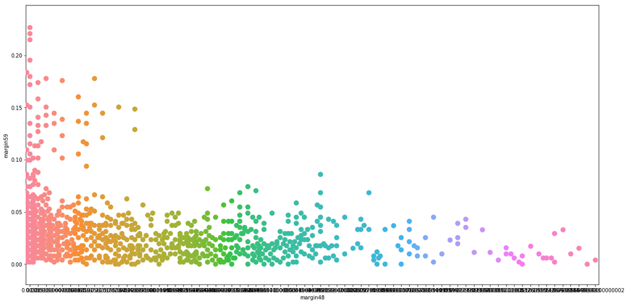

```python
import matplotlib.pyplot as plt
import seaborn as sns
plt.subplots(figsize=(20, 10))
plot_data = pd.read_csv(train_file)[['margin48', 'margin59', 'species']]
sns.swarmplot(x="margin48", y="margin59", data=train, size=10)
```

To gain more insight into what class of feature is more important for classification, let's group feature importances by class and sum the scores for each group

Join subcategories into parent category by removing digit labels

```python
feature_importances['feature'] = feature_importances['feature'].apply(lambda feature: ''.join([i for i in feature if not i.isdigit()]))
```

```python
group_feature_importance = feature_importances.groupby(by="feature").sum()
#Order the new set
group_feature_importance.sort_values(by="value", ascending = False)
```

| feature | value |
| --- | --- |
| texture | 0.352355 |
| margin | 0.340454 |
| shape | 0.307192 |

We can conculde that texture is the most discriminative feature margin comes second. If we go back to the previous feature importances df, we can see that the bottom feature can be dropped from the learning process without losing much information about the leaf characteristics therefor reducing the dimensionality of the problem and improving learning accuracy and speed up training.